# Bay Area Assignment 3

Emma Clark

12/4/2020

## Multiple Regression Analysis

### Individual income regressed against educational attainment and number of weeks worked in previous year

```r
# bay county names
bay_county_names <-
  c(
    "Alameda",
    "Contra Costa",
    "Marin",
    "Napa",
    "San Francisco",
    "San Mateo",
    "Santa Clara",
    "Solano",
    "Sonoma"
  )

bay_counties <-
  counties("CA") %>%
  filter(NAME %in% bay_county_names)
```

```r
# CHANGE VARIABLES
# ca pums (survey data)
 ca_pums <- get_pums(
  variables = c(
    "PINCP",
    "SCHL",
    "WKW",
    "PUMA"),
  state = "CA",
  year = 2018,
  survey = "acs5",
  recode = T)

# filter to pumas in Bay Area
ca_pumas <- pumas("CA", cb = T, progress_bar = F)

bay_pumas <-
  ca_pumas %>%
  st_centroid() %>%
  .[bay_counties, ] %>%
  st_set_geometry(NULL) %>%
  left_join(ca_pumas %>% select(GEOID10)) %>%
  st_as_sf()

# Bay Area subdata
bay_pums <-
  ca_pums %>%
  filter(PUMA %in% bay_pumas$PUMACE10)
```

```r
# bay pums income regression data
bay_multiple_pums <-
  bay_pums %>%
    mutate(weeks_worked = ifelse(WKW == "2", 48.5,
                                 ifelse(WKW == "3", 43.5,
                                        ifelse(WKW == "4", 33,
                                               ifelse(WKW == "5", 20,
                                                      ifelse(WKW == "6", 7,
                                                             ifelse(WKW == "1", 52, NA))))))
  ) %>%
  transmute(
    PUMA = PUMA,
    income = PINCP,
    education_level = SCHL,
    weeks_worked = weeks_worked
  ) %>%
  filter(
    !is.na(income),
    !is.na(education_level),
    !is.na(weeks_worked),
    !income == 0,
    !income == -19999,
    !education_level == "bb"
  )
```

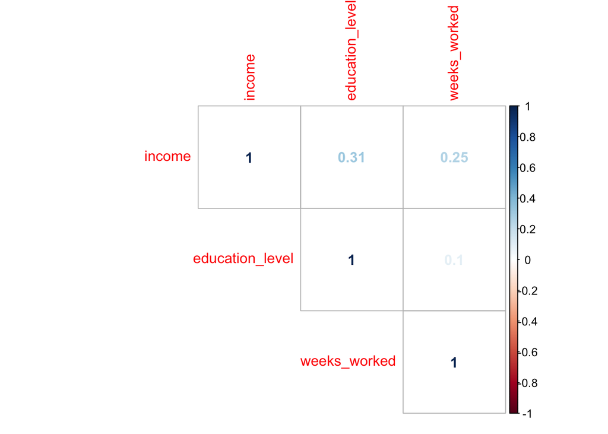

```r
bay_multiple_pums$income <- as.numeric(bay_multiple_pums$income)
bay_multiple_pums$education_level <- as.numeric(bay_multiple_pums$education_level)
bay_multiple_pums$weeks_worked <- as.numeric(bay_multiple_pums$weeks_worked)

# correlation plot
library(corrplot)

correlationplot <- bay_multiple_pums %>%
  select(
    income,
    education_level,
    weeks_worked
  ) %>%
  cor()

corrplot(
  correlationplot,
  method = "number",
  type = "upper"
)
```

Based on this correlation plot, there is essentially no relationship between education_level and weeks_worked. There is additionally a somewhat weak positive relationship between income and education_level and weeks_worked with respective correlation coefficients of 0.31 and 0.25.

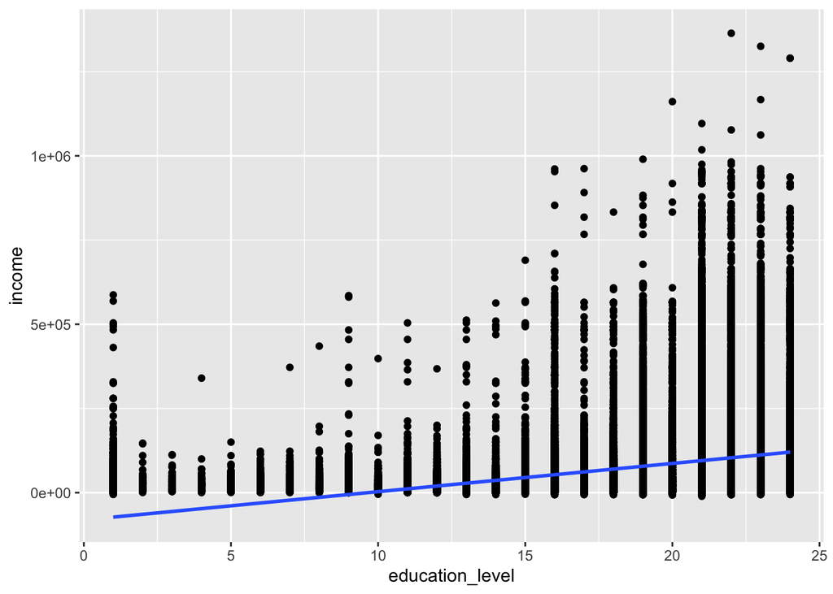

```r
ggplot(
  data = bay_multiple_pums,
  aes(
      x = education_level,
      y = income
    )
) +
  geom_point() +
  geom_smooth(method = "lm")
```

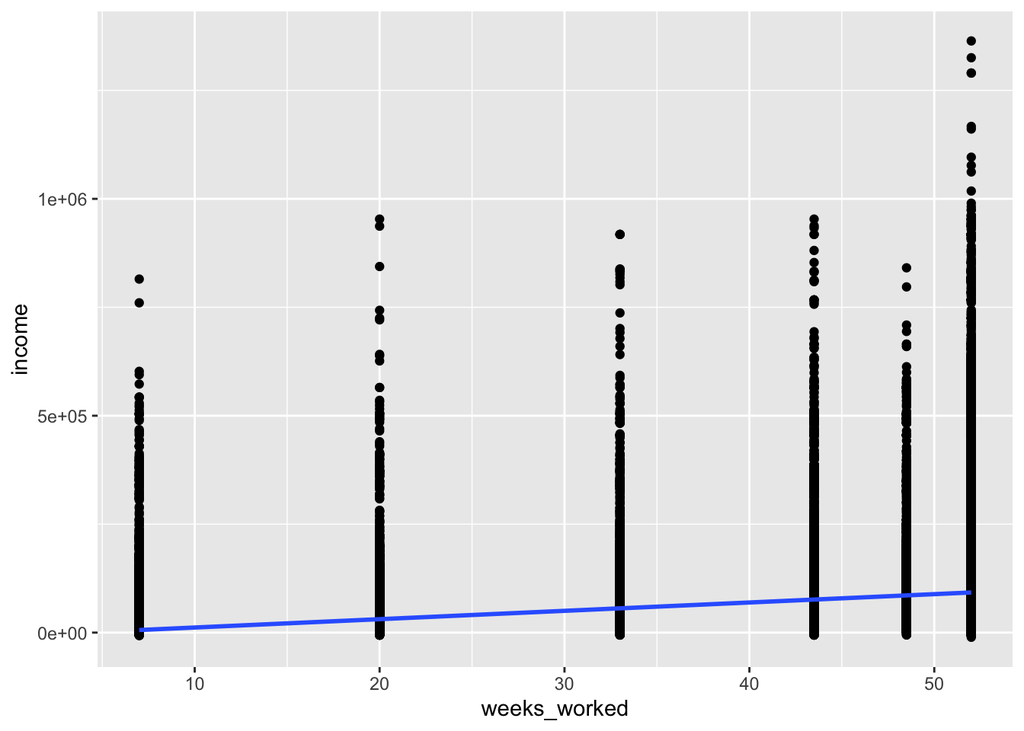

```r
ggplot(
  data = bay_multiple_pums,
  aes(
      x = weeks_worked,
      y = income
    )
) +
  geom_point() +
  geom_smooth(method = "lm")
```

Because of the discrete nature of the independent variables, the scatterplots don’t have the typical appearance. Further, it seems that income is more concentrated at the x-axis for all levels of education and number of weeks worked in the past year. Both scatterplots reveal a positve relationship between the independent variables and income, with education level having a slightly stronger association.

```r
model_pums <- lm(income ~ education_level + weeks_worked, bay_multiple_pums)

summary(model_pums)
```

```
##
## Call:
## lm(formula = income ~ education_level + weeks_worked, data = bay_multiple_pums)
##
## Residuals:
##     Min      1Q  Median      3Q     Max
## -133210  -48579  -21151   17090 1251676
##
## Coefficients:
##                   Estimate Std. Error t value Pr(>|t|)
## (Intercept)     -148057.15    1232.47  -120.1   <2e-16 ***
## education_level    7793.06      55.03   141.6   <2e-16 ***
## weeks_worked       1710.26      15.39   111.1   <2e-16 ***
## ---
## Signif. codes:  0 '***' 0.001 '**' 0.01 '*' 0.05 '.' 0.1 ' ' 1
##
## Residual standard error: 89850 on 207302 degrees of freedom
## Multiple R-squared:  0.1473, Adjusted R-squared:  0.1473
## F-statistic: 1.791e+04 on 2 and 207302 DF,  p-value: < 2.2e-16
```

This linear regression produced estimates of 7793 for education_level and 1710 for weeks_worked, confirming the positive relationship we saw with the correlation and implying that a one unit increase in either of those variables would result in an increase in income corresponding to their coefficients. The model also reveals this relationship to have enough evidence to reject the null hypothesis. However, these results should not be interpreted causally as there may be reverse causality, confounding variables, or other fundamental issues at play. The R-squared of 0.1473 can be interpreted to mean that 14% of the variation in income is explained by education_level and weeks_worked. This is somewhat low and suggests that there are other variables that could be added to the model to better account for the variation in income.

## Multiple Regression Analysis at the CBG Tract Level: 2018

### Percent of households in poverty regressed against educational attainment and employment

```r
# variables for acs 2018 5 yr
acs_vars_2018_5yr <-
  listCensusMetadata(
    name = "2018/acs/acs5",
    type = "variables"
  )
```

```r
# get variables for income, education, and employment
bay_multiple_tract <-
  getCensus(
    name = "acs/acs5",
    vintage = 2018,
    region = "tract:*",
    regionin = "state:06+county:001,013,041,055,075,081,085,095,097",
    vars = c(
      "B19001_001E",
      "B19001_002E",
      "B19001_003E",
      "B19001_004E",
      "B19001_005E",
      "B15003_001E",
      "B15003_021E",
      "B15003_022E",
      "B15003_023E",
      "B15003_024E",
      "B15003_025E",
      "C18120_006E",
      "C18120_002E"

    )
  ) %>%
  transmute(
    tract = paste0(state, county, tract),
    pct_under25k = (B19001_002E + B19001_003E + B19001_004E + B19001_005E) / B19001_001E,
    pct_collegedegree = (B15003_021E + B15003_022E + B15003_023E + B15003_024E +B15003_025E) / B15003_001E,
    pct_unemployed = C18120_006E / C18120_002E
  ) %>%
  filter(
    !is.na(pct_under25k),
    !is.na(pct_collegedegree),
    !is.na(pct_unemployed)
  )
```

I chose to investigate the relationship between poverty rates (defined based on the Federal poverty level as annual income less than $25,000) and education (attainment of college degree) along with unemployment rate. I based my choice on papers from the National Bureau of Economic Research and highlighting the relationship between poverty, education, and employment.

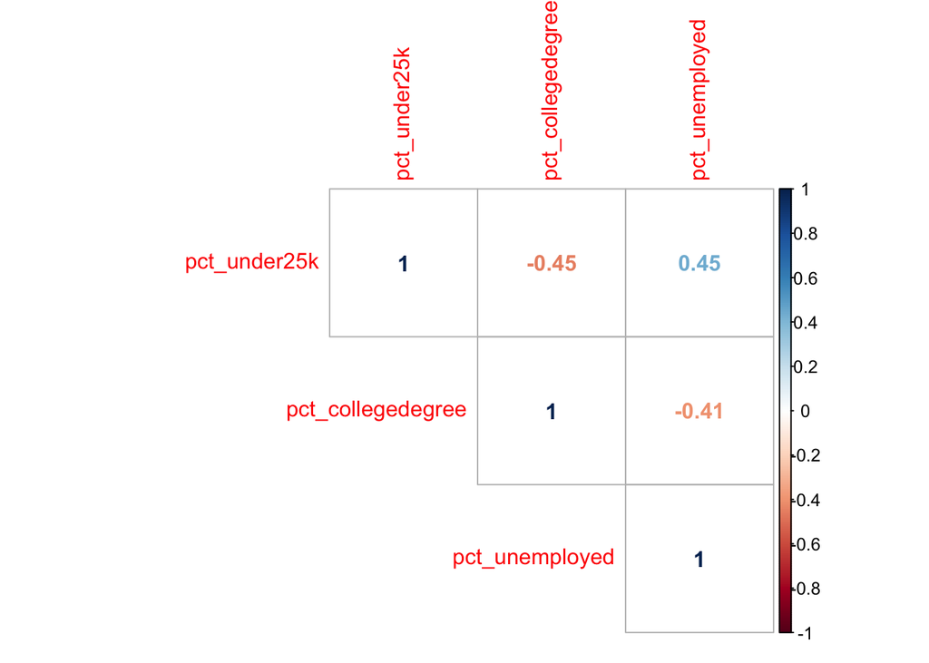

```r
# correlation plot
library(corrplot)

correlationplot <- bay_multiple_tract %>%
  select(
    pct_under25k,
    pct_collegedegree,
    pct_unemployed
  ) %>%
  cor()

corrplot(
  correlationplot,
  method = "number",
  type = "upper"
)
```

This visualization shows the correlation coefficients between the different variables of interest. The coefficient between pct_under25k and pct_collegedegree is negative, meaning increases in one is associated with decreases in the other. The coefficient between pct_under25k and pct_unemployed however is positive, meaning increases in one is associated with increases in the other. The values of .41-.45 imply a moderately strong association between the variables of interest.

```r
# linear model of percent making under 25k as a function of percent with a college degree and percent unemployed
model_cbg <- lm(pct_under25k ~ pct_collegedegree + pct_unemployed, bay_multiple_tract)

summary(model_cbg)
```

```
##
## Call:
## lm(formula = pct_under25k ~ pct_collegedegree + pct_unemployed,
##     data = bay_multiple_tract)
##
## Residuals:
##      Min       1Q   Median       3Q      Max
## -0.22684 -0.04795 -0.01299  0.03021  0.48833
##
## Coefficients:
##                    Estimate Std. Error t value Pr(>|t|)
## (Intercept)        0.155594   0.008287   18.78   <2e-16 ***
## pct_collegedegree -0.146159   0.010484  -13.94   <2e-16 ***
## pct_unemployed     1.016779   0.074963   13.56   <2e-16 ***
## ---
## Signif. codes:  0 '***' 0.001 '**' 0.01 '*' 0.05 '.' 0.1 ' ' 1
##
## Residual standard error: 0.07817 on 1574 degrees of freedom
## Multiple R-squared:  0.2894, Adjusted R-squared:  0.2885
## F-statistic: 320.5 on 2 and 1574 DF,  p-value: < 2.2e-16
```

From this linear regression, the coefficient for pct_collegedegree is -0.146 (weaker negative relationship) and the coefficient for pct_unemployed is 1.017 (stronger positive relationship). The asterisks imply that there is enough evidence to reject the null hypothesis that there isn’t a relationship between pct_under25k and the independent variables.

The R-squared indicates how much of the variance in pct_under25k is explained by the independent variables, and is a measure of the goodness of fit of this regression line. In this case, the R-squared is 0.2894, so even though there is a relationship between the independent and dependent variables, the model doesn’t explain the majority of the variation in in pct_under25k.

These results are somewhat in line with my preliminary review of relevant literature which suggested a strong relationship between poverty and unemployment, an anecdotally strong relationship between education and poverty, but the presence many other factors in determining the poverty rate of a particular area. Importantly, there is not enough evidence to interpret this relationship as causal, it’s merely evidence of a relationship between these variables that can explain some of the variation of income.

## Multiple Regression Analysis at the CBG Tract Level: 2015

### Percent of households in poverty regressed against educational attainment and employment

```r
# get variables for income, education, and employment
bay_multiple_tract2015 <-
  getCensus(
    name = "acs/acs5",
    vintage = 2015,
    region = "tract:*",
    regionin = "state:06+county:001,013,041,055,075,081,085,095,097",
    vars = c(
      "B19001_001E",
      "B19001_002E",
      "B19001_003E",
      "B19001_004E",
      "B19001_005E",
      "B15003_001E",
      "B15003_021E",
      "B15003_022E",
      "B15003_023E",
      "B15003_024E",
      "B15003_025E",
      "C18120_006E",
      "C18120_002E"

    )
  ) %>%
  transmute(
    tract = paste0(state, county, tract),
    pct_under25k = (B19001_002E + B19001_003E + B19001_004E + B19001_005E) / B19001_001E,
    pct_collegedegree = (B15003_021E + B15003_022E + B15003_023E + B15003_024E +B15003_025E) / B15003_001E,
    pct_unemployed = C18120_006E / C18120_002E
  ) %>%
  filter(
    !is.na(pct_under25k),
    !is.na(pct_collegedegree),
    !is.na(pct_unemployed)
  )
```

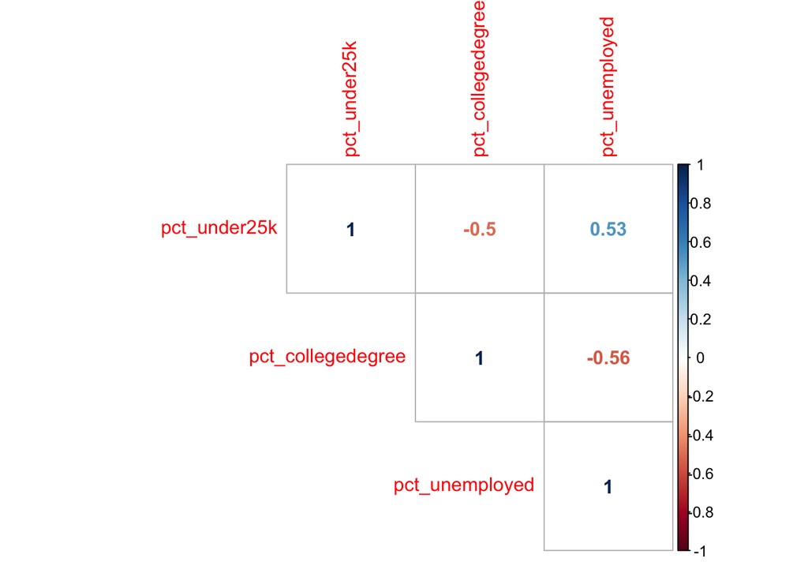

```r
# correlation plot
library(corrplot)

correlationplot <- bay_multiple_tract2015 %>%
  select(
    pct_under25k,
    pct_collegedegree,
    pct_unemployed
  ) %>%
  cor()

corrplot(
  correlationplot,
  method = "number",
  type = "upper"
)
```

These correlation coefficients are similar to those from 2018, but stronger by a factor of roughly .10. This means that in 2015, there was a stronger association between poverty rates, education attainment, and unemployment rates.

```r
# linear model of percent making under 25k as a function of percent with a college degree and percent unemployed 2015
model_cbg15 <- lm(pct_under25k ~ pct_collegedegree + pct_unemployed, bay_multiple_tract2015)

summary(model_cbg15)
```

```
##
## Call:
## lm(formula = pct_under25k ~ pct_collegedegree + pct_unemployed,
##     data = bay_multiple_tract2015)
##
## Residuals:
##      Min       1Q   Median       3Q      Max
## -0.24426 -0.05344 -0.01295  0.03568  0.58251
##
## Coefficients:
##                   Estimate Std. Error t value Pr(>|t|)
## (Intercept)        0.16104    0.01065   15.12   <2e-16 ***
## pct_collegedegree -0.15642    0.01287  -12.16   <2e-16 ***
## pct_unemployed     0.95587    0.06508   14.69   <2e-16 ***
## ---
## Signif. codes:  0 '***' 0.001 '**' 0.01 '*' 0.05 '.' 0.1 ' ' 1
##
## Residual standard error: 0.08783 on 1574 degrees of freedom
## Multiple R-squared:  0.3415, Adjusted R-squared:  0.3406
## F-statistic: 408.1 on 2 and 1574 DF,  p-value: < 2.2e-16
```

The estimates for this regression are very similar to those from 2018. Both coefficients for pct_collegedegree and pct_unemployed are slightly lower, -0.156 compared to -0.146 and 0.955 compared to 1.016. The R-squared for this regression is higher, 0.3415, meaning that this model explains 5% more variation in income than the model from 2018. Overall, it appears as though this relationship has weakened slightly but not fundamentally changed since 2015.